# DDSAnalytics

### Salary - Analysis

Bsed on the correlation coefficient, Monthly Income shows evidence of positive relationship with Age (0.484) and Job Level(0.952).

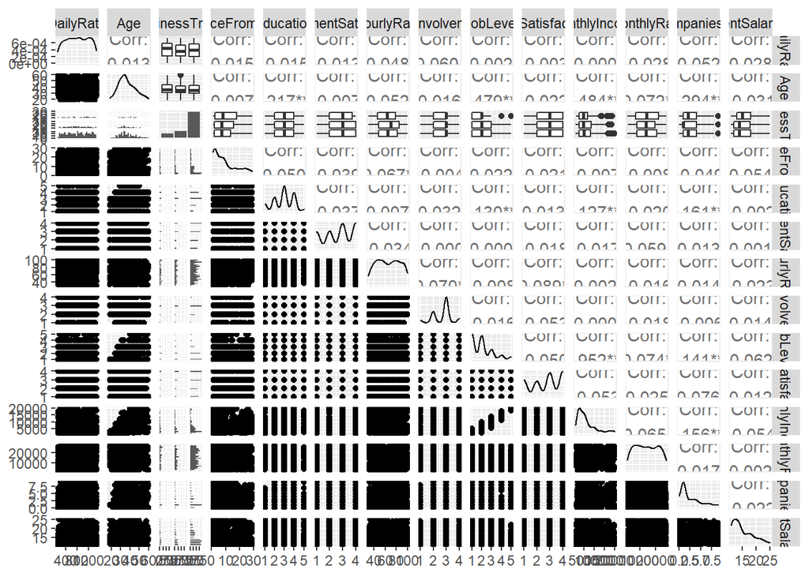

```r
data1 <- data
# Selecting quantitative variables
data1 %>%  select(DailyRate,Age,BusinessTravel,DailyRate,DistanceFromHome, Education,EnvironmentSatisfaction,HourlyRate,JobInvolvement,JobLevel,EnvironmentSatisfaction,JobSatisfaction,MonthlyIncome,MonthlyRate,NumCompaniesWorked,PercentSalaryHike) %>% ggpairs(aes())
```

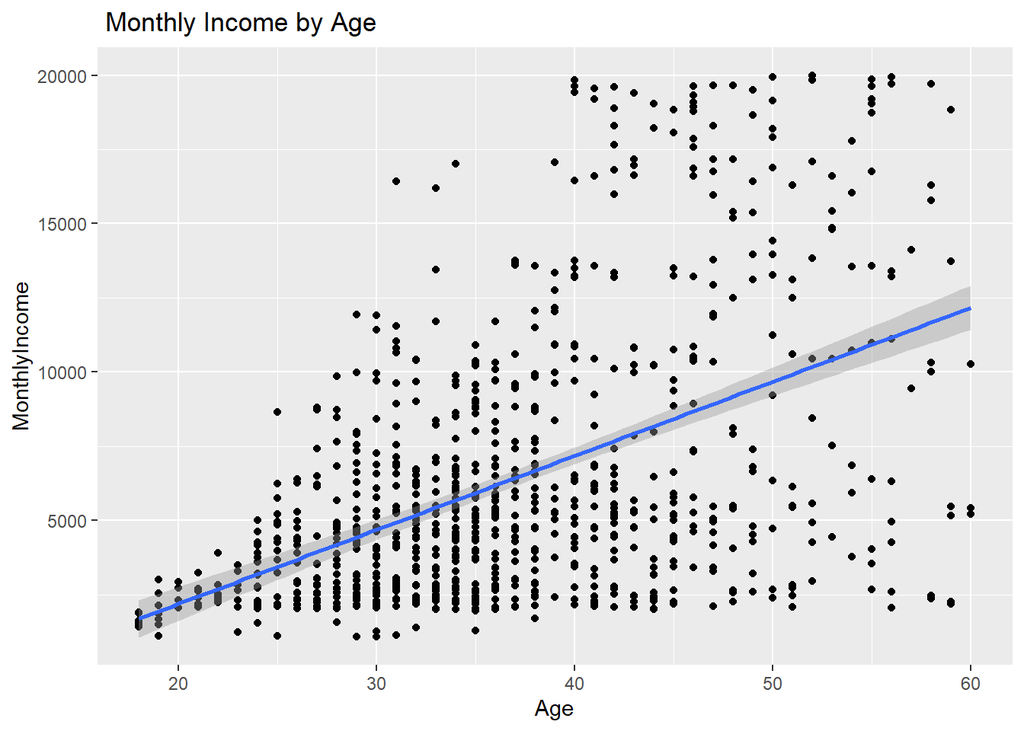

```r
data1 %>% ggplot(aes(x= Age, y=MonthlyIncome)) + geom_point() + ggtitle(" Monthly Income by Age") + geom_smooth(method = "lm")
```

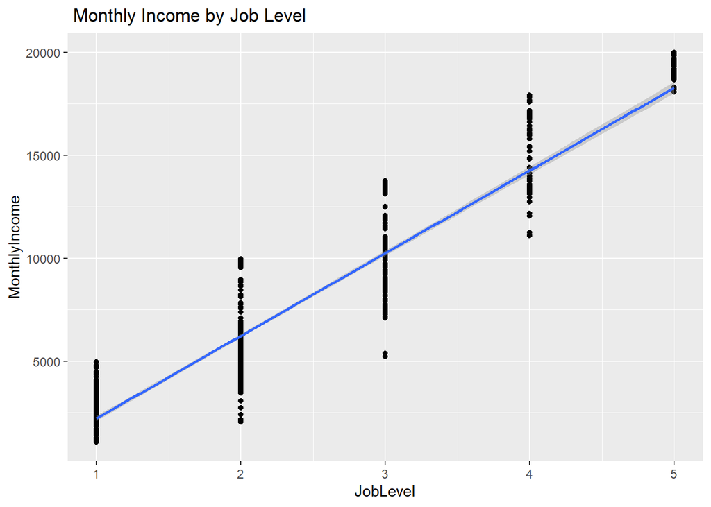

```r
data1 %>% ggplot(aes(x= JobLevel, y=MonthlyIncome)) + geom_point() + ggtitle(" Monthly Income by Job Level") + geom_smooth(method = "lm")
```

### Salary - Models

The best linear regression model was model 4 with the lowest RMSE of 1258.839 as well as the best residual density curve.

```r
# Model 1 with Job level
fit1 = lm(MonthlyIncome~JobLevel, data = data1)
summary(fit1)
```

```
##
## Call:
## lm(formula = MonthlyIncome ~ JobLevel, data = data1)
##
## Residuals:
##     Min      1Q  Median      3Q     Max
## -5037.1  -928.2    80.1   697.1  3723.6
##
## Coefficients:
##             Estimate Std. Error t value Pr(>|t|)
## (Intercept) -1793.93     101.68  -17.64   <2e-16 ***
## JobLevel     4013.67      43.98   91.26   <2e-16 ***
## ---
## Signif. codes:  0 '***' 0.001 '**' 0.01 '*' 0.05 '.' 0.1 ' ' 1
##
## Residual standard error: 1413 on 868 degrees of freedom
## Multiple R-squared:  0.9056, Adjusted R-squared:  0.9055
## F-statistic:  8329 on 1 and 868 DF,  p-value: < 2.2e-16
```

```r
confint(fit1)
```

```
##                 2.5 %    97.5 %
## (Intercept) -1993.494 -1594.375
## JobLevel     3927.352  4099.990
```

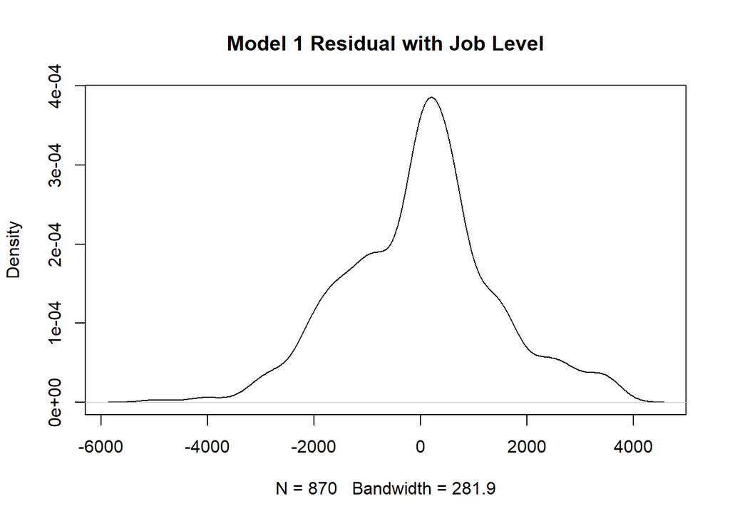

```r
res1 <-resid(fit1)
plot(density(res1),main = "Model 1 Residual with Job Level")
```

```r
RMSE1 = sqrt(mean(fit1$residuals^2))
RMSE1 # 1411.67
```

```
## [1] 1411.67
```

```r
# Model 2 with Age
fit2 = lm(MonthlyIncome~Age, data = data1)
summary(fit2)
```

```
##
## Call:
## lm(formula = MonthlyIncome ~ Age, data = data1)
##
## Residuals:
##     Min      1Q  Median      3Q     Max
## -9744.0 -2622.7  -643.3  1968.7 12651.7
##
## Coefficients:
##             Estimate Std. Error t value Pr(>|t|)
## (Intercept)  -2796.8      579.6  -4.825 1.65e-06 ***
## Age            249.4       15.3  16.308  < 2e-16 ***
## ---
## Signif. codes:  0 '***' 0.001 '**' 0.01 '*' 0.05 '.' 0.1 ' ' 1
##
## Residual standard error: 4025 on 868 degrees of freedom
## Multiple R-squared:  0.2345, Adjusted R-squared:  0.2337
## F-statistic:   266 on 1 and 868 DF,  p-value: < 2.2e-16
```

```r
confint(fit2)
```

```
##                  2.5 %     97.5 %
## (Intercept) -3934.4502 -1659.1417
## Age           219.4314   279.4758
```

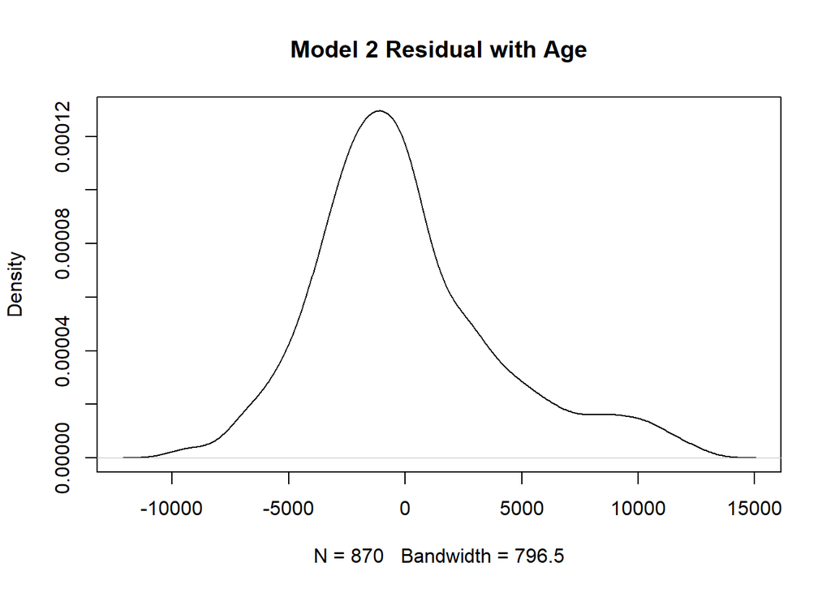

```r
res2 <-resid(fit2)
plot(density(res2),main = "Model 2 Residual with Age")
```

```r
RMSE2 = sqrt(mean(fit2$residuals^2))
RMSE2 # 4020.251
```

```
## [1] 4020.251
```

```r
# Model 3 combined JobLevel and Age
fitc = lm(MonthlyIncome~JobLevel + Age, data = data1)
summary(fitc)
```

```
##
## Call:
## lm(formula = MonthlyIncome ~ JobLevel + Age, data = data1)
##
## Residuals:
##     Min      1Q  Median      3Q     Max
## -5119.6  -954.7    67.4   734.7  3848.8
##
## Coefficients:
##              Estimate Std. Error t value Pr(>|t|)
## (Intercept) -2334.680    202.630  -11.52  < 2e-16 ***
## JobLevel     3940.027     49.871   79.00  < 2e-16 ***
## Age            18.760      6.091    3.08  0.00213 **
## ---
## Signif. codes:  0 '***' 0.001 '**' 0.01 '*' 0.05 '.' 0.1 ' ' 1
##
## Residual standard error: 1406 on 867 degrees of freedom
## Multiple R-squared:  0.9066, Adjusted R-squared:  0.9064
## F-statistic:  4210 on 2 and 867 DF,  p-value: < 2.2e-16
```

```r
confint(fitc)
```

```
##                    2.5 %      97.5 %
## (Intercept) -2732.383300 -1936.97659
## JobLevel     3842.144503  4037.90964
## Age             6.805894    30.71438
```

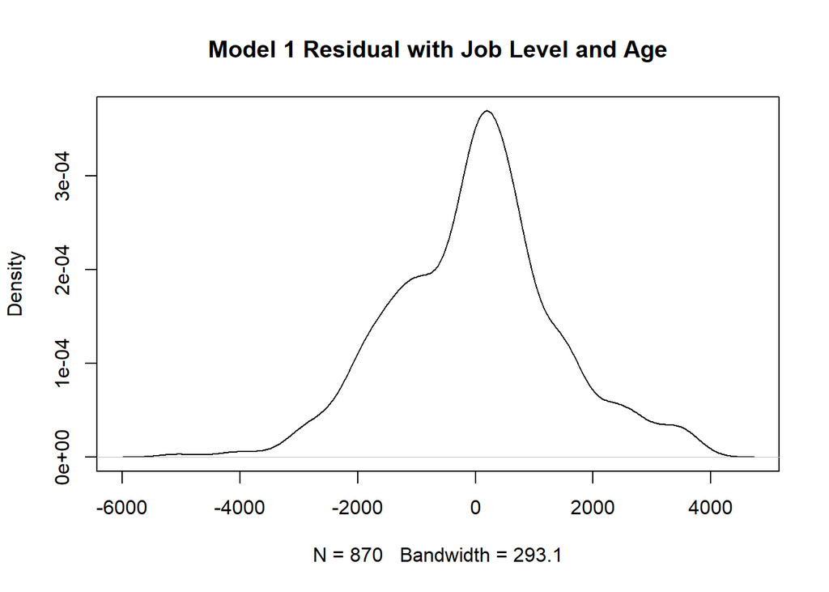

```r
resc <-resid(fitc)
plot(density(resc),main = "Model 1 Residual with Job Level and Age")
```

```r
RMSEc = sqrt(mean(fitc$residuals^2))
RMSEc # 1404.01
```

```
## [1] 1404.01
```

```r
# Model 4 combined Job level and Age^2 (Best model with lowets RMSE and highest r squared)
JI2 = data1$JobLevel * data1$JobLevel

JI3 = data1$JobLevel * data1$JobLevel * data1$JobLevel

fitc1 = lm(MonthlyIncome~ JobLevel + JI2 + JI3 + Age, data = data1)
summary(fitc1)
```

```
##
## Call:
## lm(formula = MonthlyIncome ~ JobLevel + JI2 + JI3 + Age, data = data1)
##
## Residuals:
##     Min      1Q  Median      3Q     Max
## -4859.4  -684.7  -121.4   622.5  4542.5
##
## Coefficients:
##              Estimate Std. Error t value Pr(>|t|)
## (Intercept)  2546.024    470.355   5.413 8.03e-08 ***
## JobLevel    -2152.035    618.880  -3.477 0.000532 ***
## JI2          2096.029    252.254   8.309 3.70e-16 ***
## JI3          -204.491     30.080  -6.798 1.97e-11 ***
## Age            14.144      5.477   2.582 0.009976 **
## ---
## Signif. codes:  0 '***' 0.001 '**' 0.01 '*' 0.05 '.' 0.1 ' ' 1
##
## Residual standard error: 1262 on 865 degrees of freedom
## Multiple R-squared:  0.9249, Adjusted R-squared:  0.9246
## F-statistic:  2665 on 4 and 865 DF,  p-value: < 2.2e-16
```

```r
confint(fitc1)
```

```
##                    2.5 %     97.5 %
## (Intercept)  1622.854227 3469.19438
## JobLevel    -3366.718176 -937.35251
## JI2          1600.928149 2591.13019
## JI3          -263.530125 -145.45274
## Age             3.393931   24.89355
```

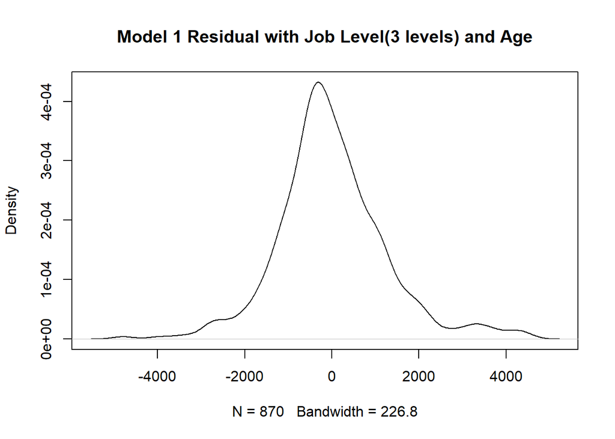

```r
res <- resid(fitc1)
plot(density(res), main = "Model 1 Residual with Job Level(3 levels) and Age")
```

```r
RMSEc1 = sqrt(mean(fitc1$residuals^2))
RMSEc1 #1258.839
```

```
## [1] 1258.839
```

```r
# Adding Predicted Salary based on Model 4 to the No Salary Dataset

Casestudy2NoS$Predicted_Salary_model4<- predict(fitc1, newdata = data.frame(JobLevel= Casestudy2NoS$JobLevel, JI2 =Casestudy2NoS$JobLevel*Casestudy2NoS$JobLevel, JI3 = Casestudy2NoS$JobLevel*Casestudy2NoS$JobLevel*Casestudy2NoS$JobLevel, Age = Casestudy2NoS$Age ), interval = "confidence")

# write.csv(Casestudy2NoS,file = 'C:\\Users\\bhand\\OneDrive\\Desktop\\Doing Data Science\\Case Study 2/Case2PredictionsBhandariSalary.csv')
```

## Conclusion

It is extremely difficult to predict attrition. Even though, I was able to create a model with good accuracy, it may not be the best model for prediction, due to various human factors involved. The best way to tackle attrition is to improve the job satisfaction by creating 5 levels for most Job Areas and not just a few.I was able to build a model which can be used to predict salary. This model may be useful to estimate a salary for any new hires based on the current Frito lay data.